# Chatlize generated report

https://Chatlize.ai

2023-07-18

### System

**Act as an experienced data scientist and statistician. Write R code to analyze data following instructions. Build a classifier to predict Sp based on all other variables in the ‘data2.csv’ file in the working folder. These columns are numeric: ASL, ASW, APL, and APW. The Sp column is either C or V.**

### Step 1

Prompt: Write R code. Do not include explanation. 1. Load the ‘data2.csv’ file into R. Show the first few rows. These columns are numeric: ASL, ASW, APL, and APW. The Sp column is either C or V.

```r
# Load the data
data <- read.csv("data2.csv")

# Show the first few rows of the data
head(data)
```

```
##   ASL ASW APL APW Sp
## 1 7.0 3.2 4.7 1.4  C
## 2 6.4 3.2 4.5 1.5  C
## 3 6.9 3.1 4.9 1.5  C
## 4 5.5 2.3 4.0 1.3  C
## 5 6.5 2.8 4.6 1.5  C
## 6 5.7 2.8 4.5 1.3  C
```

### Step 2

Prompt: Write R code. Do not include explanation. 2. Check the structure and summary statistics of the data to understand the data types and detect any missing values.

```r
# Structure of the data
str(data)
```

```
## 'data.frame':    100 obs. of  5 variables:
##  $ ASL: num  7 6.4 6.9 5.5 6.5 5.7 6.3 4.9 6.6 5.2 ...
##  $ ASW: num  3.2 3.2 3.1 2.3 2.8 2.8 3.3 2.4 2.9 2.7 ...
##  $ APL: num  4.7 4.5 4.9 4 4.6 4.5 4.7 3.3 4.6 3.9 ...
##  $ APW: num  1.4 1.5 1.5 1.3 1.5 1.3 1.6 1 1.3 1.4 ...
##  $ Sp : chr  "C" "C" "C" "C" ...
```

```r
# Summary statistics of the data
summary(data)
```

```
##       ASL             ASW             APL             APW
##  Min.   :4.900   Min.   :2.000   Min.   :3.000   Min.   :1.000
##  1st Qu.:5.800   1st Qu.:2.700   1st Qu.:4.375   1st Qu.:1.300
##  Median :6.300   Median :2.900   Median :4.900   Median :1.600
##  Mean   :6.262   Mean   :2.872   Mean   :4.906   Mean   :1.676
##  3rd Qu.:6.700   3rd Qu.:3.025   3rd Qu.:5.525   3rd Qu.:2.000
##  Max.   :7.900   Max.   :3.800   Max.   :6.900   Max.   :2.500
##       Sp
##  Length:100
##  Class :character
##  Mode  :character
##
##
##
```

### Step 3

Prompt: Write R code. Do not include explanation. Perform exploratory data analysis to gain insights into the the distribution of numeric variables, their correlation, and their relationships with the target variable (Sp). This can include histograms, scatter plots, and correlation analysis.

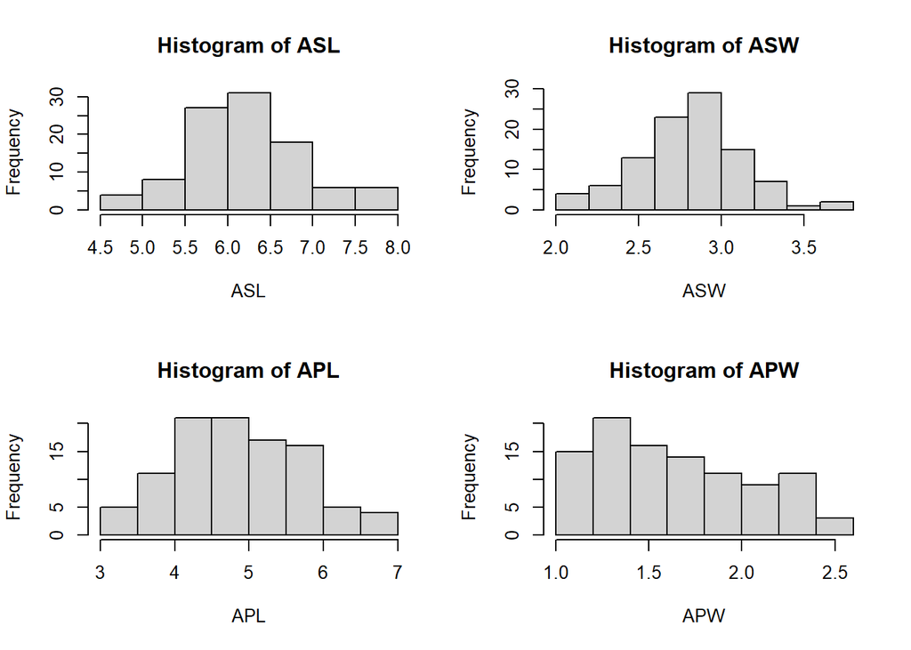

```r
# Histogram of numeric variables
par(mfrow=c(2,2))
hist(data$ASL, main="Histogram of ASL", xlab="ASL")
hist(data$ASW, main="Histogram of ASW", xlab="ASW")
hist(data$APL, main="Histogram of APL", xlab="APL")
hist(data$APW, main="Histogram of APW", xlab="APW")
```

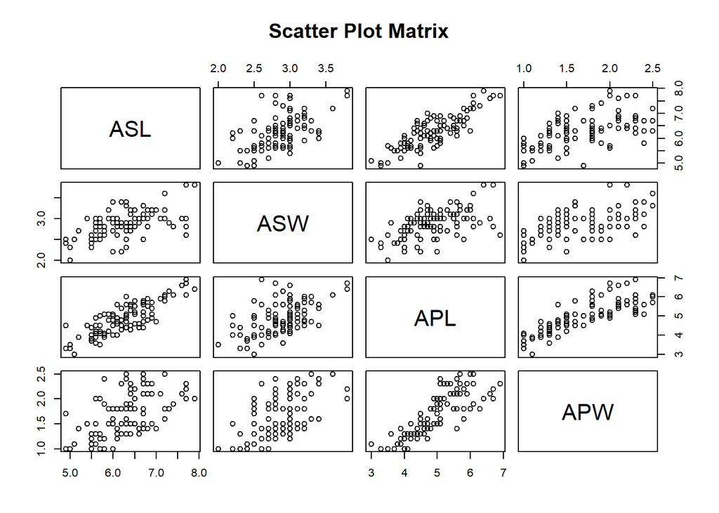

```r
# Scatter plot matrix
pairs(data[, c("ASL", "ASW", "APL", "APW")], main="Scatter Plot Matrix")
```

```r
# Correlation matrix
cor_matrix <- cor(data[, c("ASL", "ASW", "APL", "APW")])
print(cor_matrix)
```

```
##           ASL       ASW       APL       APW
## ASL 1.0000000 0.5538548 0.8284787 0.5937094
## ASW 0.5538548 1.0000000 0.5198023 0.5662025
## APL 0.8284787 0.5198023 1.0000000 0.8233476
## APW 0.5937094 0.5662025 0.8233476 1.0000000
```

### Step 4

Prompt: Write R code. Do not include explanation. Preprocess the data by ensuring all variables are in the correct format and encoding them appropriately. In this case, convert the Sp column (which contains the classes C and V) into a binary variable, such as 0 for C and 1 for V.

```r
data$Sp <- as.factor(data$Sp)
data$Sp <- as.numeric(data$Sp) - 1
```

### Step 5

Prompt: Write R code. Do not include explanation. Split the dataset into a training set and a testing set. It is recommended to allocate around 70-80% of the data for training and the remaining for testing.

```r
# Set the seed for reproducibility
set.seed(123)

# Create a vector of indices for splitting the data
indices <- sample(1:nrow(data), nrow(data)*0.8)

# Split the data into training and testing sets
train_data <- data[indices, ]
test_data <- data[-indices, ]
```

### Step 6

Prompt: Write R code. Do not include explanation. Train a logistic regression classifier on the training set using the predictor variables (ASL, ASW, APL, and APW) and the target variable (Sp).

```r
# Train a logistic regression classifier
model <- glm(Sp ~ ASL + ASW + APL + APW, data = train_data, family = binomial)

# Print the summary of the model
summary(model)
```

```
##
## Call:
## glm(formula = Sp ~ ASL + ASW + APL + APW, family = binomial,
##     data = train_data)
##
## Coefficients:
##             Estimate Std. Error z value Pr(>|z|)
## (Intercept)  -44.150     27.058  -1.632   0.1027
## ASL           -1.573      2.478  -0.635   0.5257
## ASW           -6.003      4.576  -1.312   0.1895
## APL            8.567      4.590   1.866   0.0620 .
## APW           17.448     10.350   1.686   0.0918 .
## ---
## Signif. codes:  0 '***' 0.001 '**' 0.01 '*' 0.05 '.' 0.1 ' ' 1
##
## (Dispersion parameter for binomial family taken to be 1)
##
##     Null deviance: 110.854  on 79  degrees of freedom
## Residual deviance:  10.922  on 75  degrees of freedom
## AIC: 20.922
##
## Number of Fisher Scoring iterations: 10
```

### Step 7

Prompt: Write R code. Do not include explanation. Evaluate the performance of the classifier on the training data. Print a confusion matrix.

```r
# Predict the classes on the training data
train_pred <- ifelse(predict(model, type="response") > 0.5, 1, 0)

# Create a confusion matrix for the training data
train_cm <- table(Actual = train_data$Sp, Predicted = train_pred)
print(train_cm)
```

```
##       Predicted
## Actual  0  1
##      0 38  1
##      1  1 40
```

### Step 8

Prompt: Write R code. Do not include explanation. 8. Evaluate the performance of the trained classifier on the testing set by calculating appropriate metrics such as accuracy, precision, recall, and F1 score.

```r
# Predict the classes on the testing data
test_pred <- ifelse(predict(model, newdata = test_data, type="response") > 0.5, 1, 0)

# Create a confusion matrix for the testing data
test_cm <- table(Actual = test_data$Sp, Predicted = test_pred)

# Calculate accuracy
accuracy <- sum(diag(test_cm)) / sum(test_cm)
print(paste("Accuracy:", accuracy))
```

```
## [1] "Accuracy: 1"
```

```r
# Calculate precision
precision <- test_cm[2,2] / sum(test_cm[,2])
print(paste("Precision:", precision))
```

```
## [1] "Precision: 1"
```

```r
# Calculate recall
recall <- test_cm[2,2] / sum(test_cm[2,])
print(paste("Recall:", recall))
```

```
## [1] "Recall: 1"
```

```r
# Calculate F1 score
f1_score <- 2 * (precision * recall) / (precision + recall)
print(paste("F1 Score:", f1_score))
```

```
## [1] "F1 Score: 1"
```

### Step 9

Prompt: Write R code. Do not include explanation. Draw the ROC curve for this performance and calculate AUC.

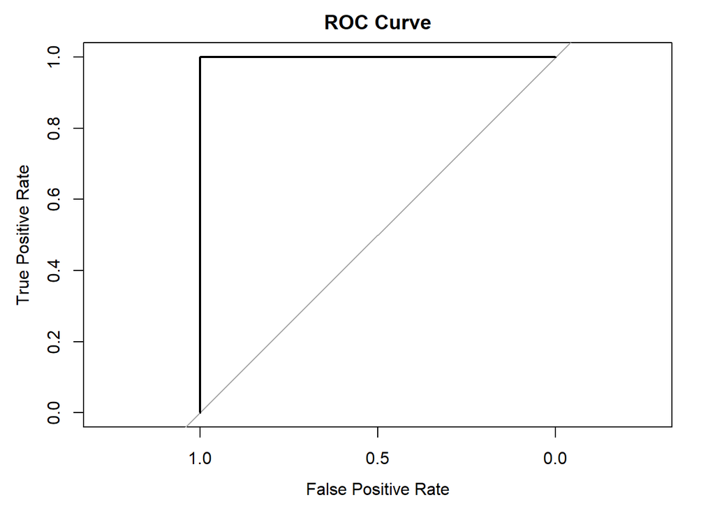

```r
# Calculate the predicted probabilities for the test data
probabilities <- predict(model, newdata = test_data, type = "response")

# Create the ROC curve
roc <- roc(test_data$Sp, probabilities)

# Plot the ROC curve
plot(roc, main = "ROC Curve", xlab = "False Positive Rate", ylab = "True Positive Rate")
```

```r
# Calculate the AUC
auc <- auc(roc)
print(paste("AUC:", auc))
```

```
## [1] "AUC: 1"
```

### Step 10

Prompt: Write R code. Do not include explanation. Repeat the analysis using decision tree.

```r
# Load the required library
pacman::p_load(rpart)

# Train a decision tree classifier
tree_model <- rpart(Sp ~ ASL + ASW + APL + APW, data = train_data, method = "class")

# Print the decision tree model
print(tree_model)
```

```
## n= 80
##
## node), split, n, loss, yval, (yprob)
##       * denotes terminal node
##
## 1) root 80 39 1 (0.48750000 0.51250000)
##   2) APW< 1.65 42  4 0 (0.90476190 0.09523810)
##     4) APL< 4.85 35  0 0 (1.00000000 0.00000000) *
##     5) APL>=4.85 7  3 1 (0.42857143 0.57142857) *
##   3) APW>=1.65 38  1 1 (0.02631579 0.97368421) *
```

```r
# Predict the classes on the training data
train_pred_tree <- predict(tree_model, type = "class")

# Create a confusion matrix for the training data
train_cm_tree <- table(Actual = train_data$Sp, Predicted = train_pred_tree)
print(train_cm_tree)
```

```
##       Predicted
## Actual  0  1
##      0 35  4
##      1  0 41
```

```r
# Predict the classes on the testing data
test_pred_tree <- predict(tree_model, newdata = test_data, type = "class")

# Create a confusion matrix for the testing data
test_cm_tree <- table(Actual = test_data$Sp, Predicted = test_pred_tree)
print(test_cm_tree)
```

```
##       Predicted
## Actual  0  1
##      0 10  1
##      1  0  9
```

```r
# Calculate accuracy
accuracy_tree <- sum(diag(test_cm_tree)) / sum(test_cm_tree)
print(paste("Accuracy:", accuracy_tree))
```

```
## [1] "Accuracy: 0.95"
```

```r
# Calculate precision
precision_tree <- test_cm_tree[2,2] / sum(test_cm_tree[,2])
print(paste("Precision:", precision_tree))
```

```
## [1] "Precision: 0.9"
```

```r
# Calculate recall
recall_tree <- test_cm_tree[2,2] / sum(test_cm_tree[2,])
print(paste("Recall:", recall_tree))
```

```
## [1] "Recall: 1"
```

```r
# Calculate F1 score
f1_score_tree <- 2 * (precision_tree * recall_tree) / (precision_tree + recall_tree)
print(paste("F1 Score:", f1_score_tree))
```

```
## [1] "F1 Score: 0.947368421052632"
```

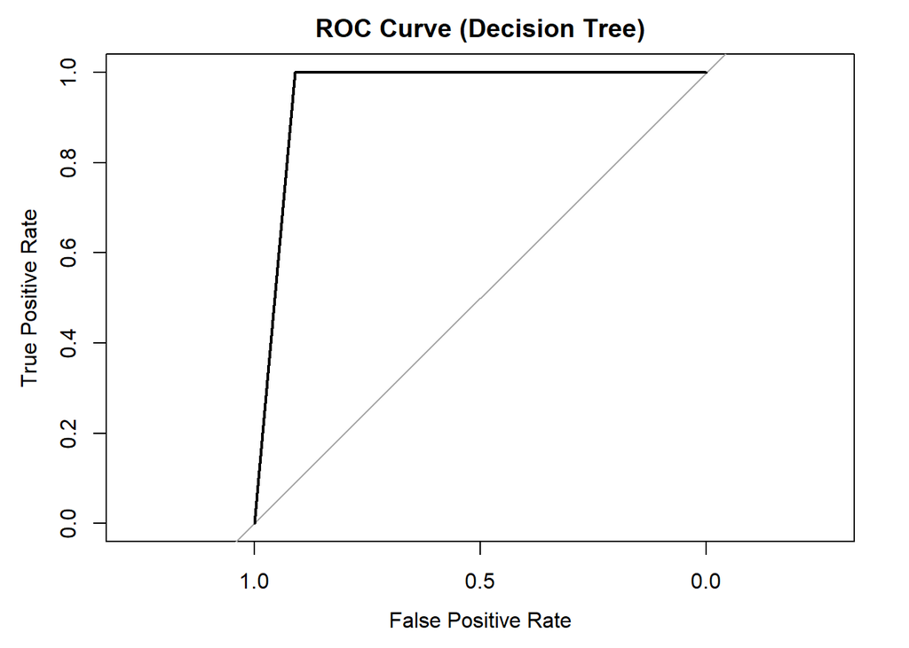

```r
# Calculate the predicted probabilities for the test data
probabilities_tree <- predict(tree_model, newdata = test_data, type = "prob")[,2]

# Create the ROC curve
roc_tree <- roc(test_data$Sp, probabilities_tree)

# Plot the ROC curve
plot(roc_tree, main = "ROC Curve (Decision Tree)", xlab = "False Positive Rate", ylab = "True Positive Rate")
```

```r
# Calculate the AUC
auc_tree <- auc(roc_tree)
print(paste("AUC:", auc_tree))
```

```
## [1] "AUC: 0.954545454545455"
```

Generated with https://Chatlize.ai. No guarantees! Still a work in progress. Contact Steven Ge (gexijin@gmail.com).